# Modelos

## KNN

### Interpretación

El en un punto “X” posicionado en 20000 y un punto “Y” posicionado en 700 la probabilidad de que este sea clasificado como clase “A” es decir los gastos monetarios de la experiencia del personal que trabaj ena reas del covid acorde con su tiempo de experiencia, este estará clasificado en un 40% por la clase A, un 60% por la clase B y un 0% por la clase C que es la “más pagada”

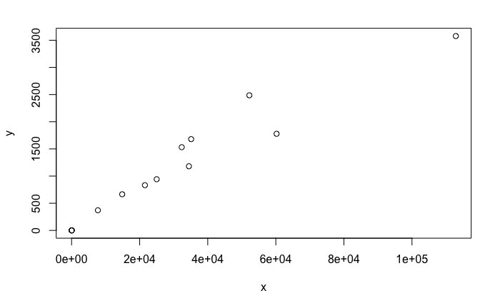

```r
#KNN
library(tidyverse)
library(lubridate)
library(readxl)

#Read
covid_19 = read_xlsx("Data/Covid-19 Daily Financial Report.xlsx")

#Quitar valores anomalos
covid_19 = covid_19[-c(1:8,16,18,20,22:24,29:31),]

#View
#plot(covid_19)
#View(covid_19)


x=covid_19$`Est. Personnel Exp`
y=covid_19$`Total Hours`

df<-data.frame(x,y)
plot(df)
```

```r
###Etiquetar (categorizar)
etiquetar<-function(df){
  categorias<-c()
  for(i in 1:NROW(df)){
    if(df$x[i]>=0 & df$x[i]<20000)
      categorias<-c(categorias,'A')
    else if(df$x[i]>=20000& df$x[i]<40000)
      categorias<-c(categorias,'B')
    else categorias<-c(categorias,'C')
  }
  df<-cbind(df,categorias)
  return (df)
}
df=etiquetar(df)
df
```

| x | y | categorias |
| --- | --- | --- |
| 60221.30 | 1778.25 | C |
| 52221.80 | 2486.51 | C |
| 24994.42 | 942.00 | B |
| 21537.94 | 832.50 | B |
| 32354.32 | 1531.65 | B |
| 112880.87 | 3576.91 | C |
| 35124.05 | 1680.00 | B |
| 34464.25 | 1180.16 | B |
| 0.00 | 0.00 | A |
| 24.62 | 1.00 | A |

[output cut: 4 more lines]

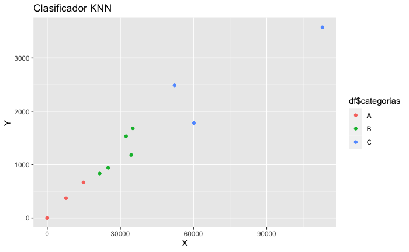

```r
#######Visualizando el df
library(ggplot2)
ggplot(data = df,aes(x=df$x,y=df$y,color=df$categorias))+
  geom_point()+xlab("X")+ylab("Y")+ggtitle("Clasificador KNN")
```

```r
#datos para entrenamiento
ids=sample(1:nrow(df),0.80*nrow(df)) #muestreo aleatorio
dfEnt<-df[ids,]
nrow(dfEnt)
```

```
[1] 11
```

```r
dfTest<-df[-ids,]
nrow(dfTest)
```

```
[1] 3
```

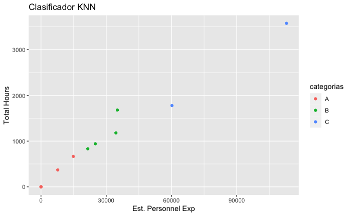

```r
ggplot(data = dfEnt ,aes(x=x,y=y,color=categorias))+
  geom_point()+xlab("Est. Personnel Exp")+ylab("Total Hours")+ggtitle("Clasificador KNN")
```

```r
dFTemp=df
knn<-function(dFTemp,newX,newY,k, method){
  if(method==1){
    d<-(abs(newX-dFTemp$x)+abs(newY-dFTemp$y))
  }else{
    d<-sqrt((newX-dFTemp$x)^2+(newY-dFTemp$y)^2)
  }
  dFTemp<-cbind(dFTemp,d)
  dFTemp
  vOrden<-sort(dFTemp$d)
  vecinos<-dFTemp[dFTemp$d %in% vOrden[1:k],3]
  return (vecinos[1:k] )
}

v<-knn(df,20000,700,5,2)
v
```

```
[1] "B" "B" "B" "A" "A"
```

```r
porc<-function(vector,value){
  return (sum(as.integer(vector==value)))
}
a<-porc(v,"A")
b<-porc(v,"B")
c<-porc(v,"C")
total<-(a+b+c)
a*100/total
```

```
[1] 40
```

```r
b*100/total
```

```
[1] 60
```

```r
c*100/total
```

```
[1] 0
```

```r
# El en un punto "X" posicionado en 20000 y un punto "Y" posicionado en 700
# la probabilidad de que este sea clasificado como clase "A" es decir los gastos
# monetarios de la experiencia del personal que trabaj ena reas del covid acorde
# con su tiempo de experiencia, este estarÃ¡ clasificado en un 40% por la clase A,
# un 60% por la clase B y un 0% por la clase C que es la "mÃ¡s pagada"
```